# Homework: Statistical Modeling and Interpretation

Due Thursday, November 12, 2026, 11:59 pm (Pacific)

Author

Hangyu Li

Published

October 27, 2026

## Instructions

This homework focuses on **interpretation and presentation of statistical results**. You will apply linear regression (with categorical predictors and interactions) and logistic regression to the Bechdel Test movie dataset.

**Total Points: 100**

1. **Linear Regression** (30 points)
2. **Logistic Regression** (30 points)
3. **Comprehensive Analysis** (25 points)
4. **Same Data, Different Goals** (15 points)

**Submission Requirements:**

- Self-contained HTML document with code hidden (use `code-fold: true`)
- Focus on clear interpretation of results, not code mechanics
- Please DO NOT use any LLMs in writing your answers. No tool is required, and no one is advantaged by paying for one (see the syllabus AI Policy).
- **Where AI would fail here:** AI often gives textbook-generic interpretations that misstate coefficient meanings (for example, treating log-odds as probabilities), claim assumptions are satisfied without looking at your diagnostic plots, and invent p-values or effect sizes. Your interpretation of *your* output is what is graded.
- **Homework check:** I may ask you to briefly explain one of your solutions in the Wednesday section (random sample, about 5 minutes).
- Include well-formatted tables and figures
- Write results as if for a technical report

## Background: The Bechdel Test

The Bechdel Test measures female representation in films. A movie passes if it has:

1. At least two named women
2. Who talk to each other
3. About something besides a man

In the data, `clean_test` records where each movie stops: `nowomen` (fewer than two named women), `notalk` (they don’t talk to each other), `men` (they only talk about a man), `dubious` (disputed), or `ok` (passes). The variable `binary` is `PASS` only for `ok`; everything else, including `dubious`, is `FAIL`.

## The Goal of This Homework: Description

As we saw in Week 5, the same model can be used to **describe**, to **infer** or to **predict**, and the goal changes what you report and what you check. **In this homework the goal is description.**

The data are 1794 movies released between 1970 and 2013 that FiveThirtyEight could match between [BechdelTest.com](https://bechdeltest.com/) (ratings submitted by volunteers) and [The-Numbers.com](https://www.the-numbers.com/) (budget and revenue). This is not a random sample of all movies: it leans toward movies that are popular enough for someone to rate them and for their finances to be public.

So every research question below asks: **what patterns are there in these movies?** Some movies have missing values, so each model will use fewer than 1794; report how many movies each model uses. In your answers:

- Describe associations in these movies. Write “among these movies, …” and not “movies in general …”
- Do not make causal claims. A coefficient for budget is not “the effect of spending one more dollar”
- Report effect sizes (coefficients, odds ratios, fitted values) and show them in figures. When p-values and confidence intervals are requested, treat them as a rough guide to how precisely these data pin down a pattern, not as a claim about a population
- Check the assumptions that matter for description: is a straight line (or the model you chose) an honest summary of the pattern?

### Recommended: Use the PCS Framework

We recommend framing your analysis with Yu & Barter’s **PCS framework** from Week 3 ([*Veridical Data Science*](https://vdsbook.com/), Ch. 1-2): is each pattern you describe real, or a product of noise and your own choices?

- **Predictability:** Does the pattern reemerge in data you didn’t use to find it, for example in a held-out half of the movies? Is it consistent with what you know about the movie industry?
- **Computability:** Every number in your report comes from code in the document. Every judgment call (log scale or not, units, rows dropped, how you treat `dubious`) is a line of code with a comment saying *why*. Use `set.seed()` before anything random.
- **Stability:** Does your conclusion survive reasonable alternative choices? For example: raw vs. log scale, dropping the few biggest blockbusters, or treating `dubious` movies as missing instead of `FAIL`.

You don’t need to run every check for every question. Pick the ones that matter most for your conclusions and mention them briefly in your write-up.

## Load the Data

```r
library(tidyverse)
library(broom)
library(knitr)

# Load the movies dataset (1970-2013)
# Missing values are coded as "#N/A" or "N/A" in the file
movies <- readr::read_csv('https://raw.githubusercontent.com/rfordatascience/tidytuesday/master/data/2021/2021-03-09/movies.csv',
                          na = c("", "NA", "#N/A", "N/A"))
# Preview
glimpse(movies)
```

```
Rows: 1,794
Columns: 34
$ year          <dbl> 2013, 2012, 2013, 2013, 2013, 2013, 2013, 2013, 2013, 20…
$ imdb          <chr> "tt1711425", "tt1343727", "tt2024544", "tt1272878", "tt0…
$ title         <chr> "21 &amp; Over", "Dredd 3D", "12 Years a Slave", "2 Guns…
$ test          <chr> "notalk", "ok-disagree", "notalk-disagree", "notalk", "m…
$ clean_test    <chr> "notalk", "ok", "notalk", "notalk", "men", "men", "notal…
$ binary        <chr> "FAIL", "PASS", "FAIL", "FAIL", "FAIL", "FAIL", "FAIL", …
$ budget        <dbl> 1.30e+07, 4.50e+07, 2.00e+07, 6.10e+07, 4.00e+07, 2.25e+…
$ domgross      <dbl> 25682380, 13414714, 53107035, 75612460, 95020213, 383624…
$ intgross      <dbl> 42195766, 40868994, 158607035, 132493015, 95020213, 1458…
$ code          <chr> "2013FAIL", "2012PASS", "2013FAIL", "2013FAIL", "2013FAI…
$ budget_2013   <dbl> 13000000, 45658735, 20000000, 61000000, 40000000, 225000…
$ domgross_2013 <dbl> 25682380, 13611086, 53107035, 75612460, 95020213, 383624…
$ intgross_2013 <dbl> 42195766, 41467257, 158607035, 132493015, 95020213, 1458…
```

[output cut: 21 more lines]

**Key Variables:**

- `binary`: Pass/Fail the Bechdel test
- `clean_test`: Where the movie stops on the test (`nowomen`, `notalk`, `men`, `dubious`, `ok`)
- `budget_2013`: Movie budget (adjusted to 2013 dollars)
- `domgross_2013`: Domestic gross revenue (2013 dollars)
- `intgross_2013`: International gross revenue (2013 dollars)
- `year`: Release year
- `imdb_rating`: IMDB rating (1-10 scale)
- `metascore`: Metacritic score (0-100)
- `rated`: MPAA rating (G, PG, PG-13, R, etc.)

Budgets and revenues are in dollars. Consider dividing them by 1,000,000 so that coefficients are per million dollars and easier to read.

## Question 1: Linear Regression (30 points)

**Research Question (descriptive):** Among these movies, how does domestic gross revenue change with budget? Is that pattern different for movies that pass vs. fail the Bechdel test?

You are describing how revenue and budget move together in this dataset, and whether the line looks different for the two groups. You are *not* estimating how much extra revenue a studio would get by spending more, and not predicting the revenue of future movies.

### Part A: Model Fitting (10 points)

Fit a linear regression model relating domestic gross revenue to budget, Bechdel test result (binary), and their interaction. Include a plot of the data with one fitted line per Bechdel group.

```r
# Your code here
# Hint: You may need to clean data (remove NAs, log-transform if appropriate)

movies_clean <- movies |>
  mutate(binary = as.factor(binary),
  budget_million = budget_2013/1e6,
  domgross_million = domgross_2013/1e6) |>
  select(title, binary, budget_million, domgross_million) |>
  drop_na()

m1 <- movies_clean |> lm(domgross_million ~ budget_million + binary + budget_million:binary, data= _)
summary(m1)
```

```
Call:
lm(formula = domgross_million ~ budget_million + binary + budget_million:binary,
    data = movies_clean)

Residuals:
    Min      1Q  Median      3Q     Max
-291.71  -49.85  -23.66   13.79 1683.61

Coefficients:
                          Estimate Std. Error t value Pr(>|t|)
(Intercept)                48.5435     5.2378   9.268  < 2e-16 ***
budget_million              0.9351     0.0607  15.405  < 2e-16 ***
binaryPASS                -26.4473     7.5819  -3.488 0.000498 ***
budget_million:binaryPASS   0.2969     0.1015   2.926 0.003480 **
---
Signif. codes:  0 '***' 0.001 '**' 0.01 '*' 0.05 '.' 0.1 ' ' 1

Residual standard error: 111.5 on 1772 degrees of freedom
Multiple R-squared:  0.2183,    Adjusted R-squared:  0.217
F-statistic:   165 on 3 and 1772 DF,  p-value: < 2.2e-16
```

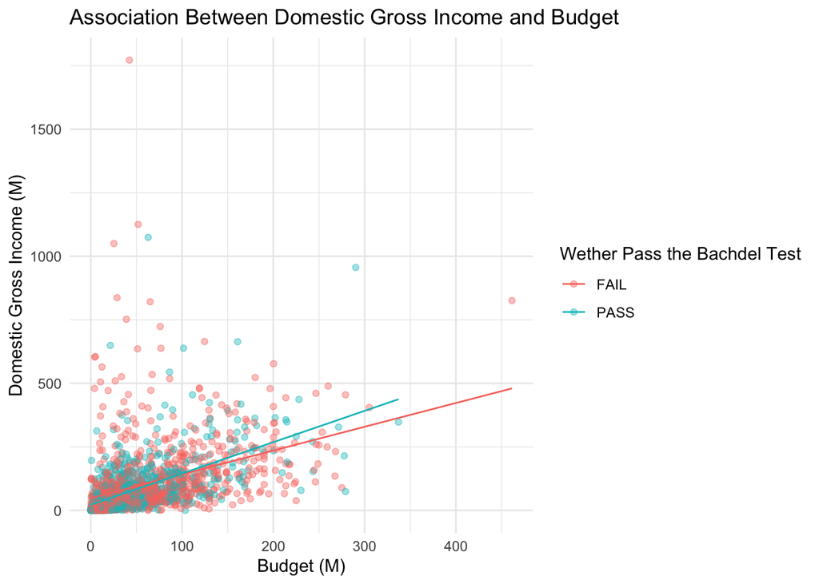

```r
ggplot(movies_clean, aes(x = budget_million, y = domgross_million, colour = binary)) +
  geom_point(alpha = 0.4) +
  geom_line(aes(y = m1$fitted.values)) +
  theme_minimal() +
  labs(title = "Association Between Domestic Gross Income and Budget",
  x = "Budget (M)", y = "Domestic Gross Income (M)",
  colour = "Wether Pass the Bachdel Test")
```

### Part B: Interpretation (10 points)

In 3-4 sentences, interpret:

1. The coefficient for budget, as a description of these movies
2. The coefficient for the interaction term: how different are the two fitted lines?
3. The practical significance of your findings: is the difference between groups large enough to matter?

**Your interpretation here:**

1. The coefficient for budget is 0.9351, which means the predicted domestic gross income of a movie that does not pass the Bechdel test will increase 0.9351 million dolloars on average as the budget of the movie increases for 1 million dollars.
2. The coefficient for interaction term is 0.2969, which means that the slope for movies that pass the Bechdel test is 0.2969 higher than that for movies that do not pass. It indicates that the predicted domestic gross income of a movie that passes the Bechdel test will increase (0.9351+0.2969) = 1.232 million dolloars on average as the budget of the movie increases for 1 million dollars.
3. The t-test for both binary variable and the interaction term both indicate that the difference between groups is statistically large enough to matter since the p-values are smaller than 0.05 and can suggest that at 5% significance level, we can reject the H_0 of the t-test.

### Part C: Diagnostic Plots (10 points)

Create 2 diagnostic plots and briefly comment on whether model assumptions are reasonably met. For description, focus on whether the fitted lines are an honest summary of the data (for example, curvature, or a few huge blockbusters driving the fit).

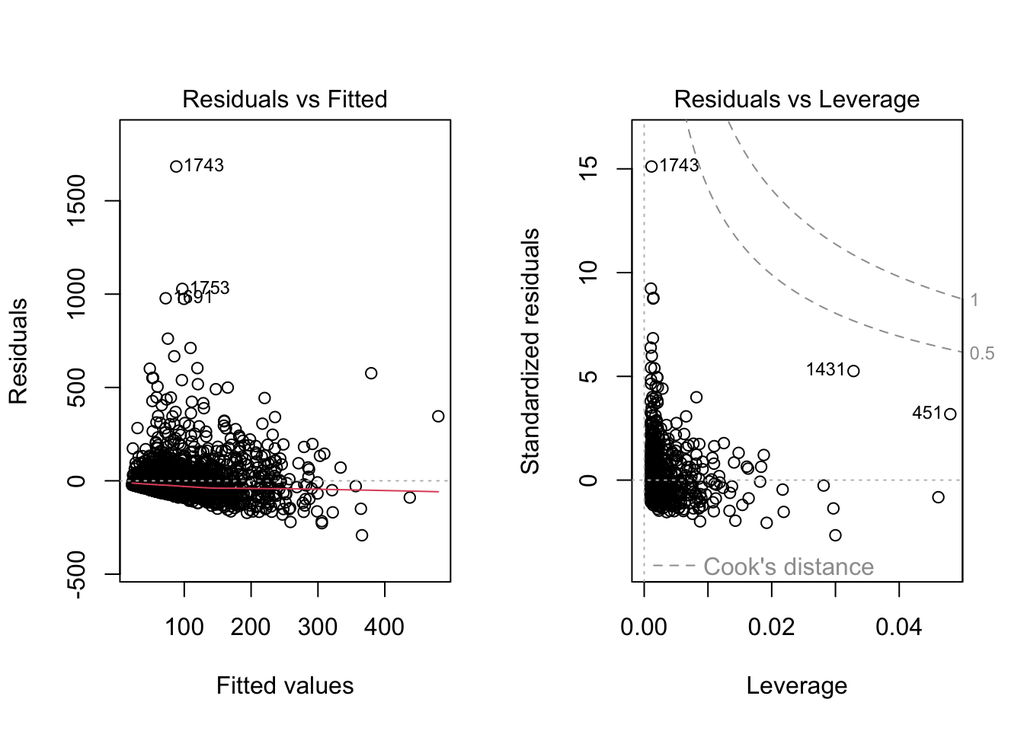

```r
# Your diagnostic plots here
library(patchwork)
par(mfrow = c(1, 2))
plot(m1, which = c(1,5))
```

```r
movies_clean[c(451, 1431,1743),]
```

```
# A tibble: 3 × 4
  title     binary budget_million domgross_million
  <chr>     <fct>           <dbl>            <dbl>
1 Avatar    FAIL            461.              826.
2 Titanic   PASS            290.              956.
3 Star Wars FAIL             42.3            1772.
```

**Comment on assumptions (2-3 sentences):**

From the left panel, the line is almost flat indicating that there is no clear curvature and the assumption of linearity is satisfied. From the right panel, we can observe some extreme values including Avatar, Titanic and Star Wars which are the hugebusters. However, their Cook’s distance don’t exceed 0.5 which means there is no clear evidence showing they strongly influence our fit.

## Question 2: Logistic Regression (30 points)

**Research Question (descriptive):** Among these movies, which characteristics are associated with passing the Bechdel test? In particular, did the share of movies that pass change between 1970 and 2013, once we account for budget and IMDB rating?

You are describing which kinds of movies in this dataset tend to pass. You are *not* building a tool to predict whether a new movie will pass, and not claiming that a bigger budget or a better rating causes a movie to pass (or the other way around).

### Part A: Model Fitting (10 points)

Fit a logistic regression model relating Bechdel test pass/fail to budget, year, and IMDB rating.

```r
# Your code here
# Note: Create a binary outcome (0/1) from the 'binary' variable

movies_clean <- movies |>
  mutate(binary = factor(binary, levels = c("FAIL", "PASS")),
  budget_million = budget_2013/1e6,
  decade = year/10) |>
  select(title, decade, binary, budget_million, imdb_rating) |>
  drop_na()

m2 <- movies_clean |> glm(binary ~ budget_million + decade + imdb_rating,
    data = _,family = binomial(link = 'logit'))
summary(m2)
```

```
Call:
glm(formula = binary ~ budget_million + decade + imdb_rating,
    family = binomial(link = "logit"), data = movies_clean)

Coefficients:
                 Estimate Std. Error z value Pr(>|z|)
(Intercept)    -34.798795  12.016034  -2.896  0.00378 **
budget_million  -0.006554   0.001043  -6.285 3.28e-10 ***
decade           0.184357   0.059735   3.086  0.00203 **
imdb_rating     -0.297680   0.055592  -5.355 8.57e-08 ***
---
Signif. codes:  0 '***' 0.001 '**' 0.01 '*' 0.05 '.' 0.1 ' ' 1

(Dispersion parameter for binomial family taken to be 1)

    Null deviance: 2183.8  on 1591  degrees of freedom
Residual deviance: 2098.6  on 1588  degrees of freedom
AIC: 2106.6

Number of Fisher Scoring iterations: 4
```

### Part B: Coefficient Interpretation (10 points)

Present a table of odds ratios with 95% confidence intervals. Interpret the odds ratio for year in context. Make sure the units of each odds ratio make sense to a reader (for example, per million dollars of budget, or per decade instead of per year).

```r
# Your table here (consider using tidy() and exp() for odds ratios)
tidy(m2, conf.int = TRUE, conf.level = 0.95, exponentiate = TRUE) |>
  select(term, estimate, conf.low, conf.high)
```

```
# A tibble: 4 × 4
  term           estimate conf.low conf.high
  <chr>             <dbl>    <dbl>     <dbl>
1 (Intercept)    7.71e-16 3.77e-26 0.0000112
2 budget_million 9.93e- 1 9.91e- 1 0.995
3 decade         1.20e+ 0 1.07e+ 0 1.35
4 imdb_rating    7.43e- 1 6.65e- 1 0.827
```

**Interpretation (4-5 sentences):**

The odds ratio for year is 1.20, which means that holding budgets and imdb ratings the same, the odds for a movie to pass the Bechdel test will increase 20% as 10 years pass. The 95% confidence interval is (1.07, 1.35), suggesting that the odds increase by 7% to 35% per decade. This suggests that the more recent a movie is, the odds of passing the Bechdel test after accounting for budget and IMDB rating will be higher.

### Part C: Fitted Probabilities and Visualization (10 points)

Create a visualization showing the fitted probability of passing the Bechdel test over time (holding other variables at their means). Include confidence bands if possible.

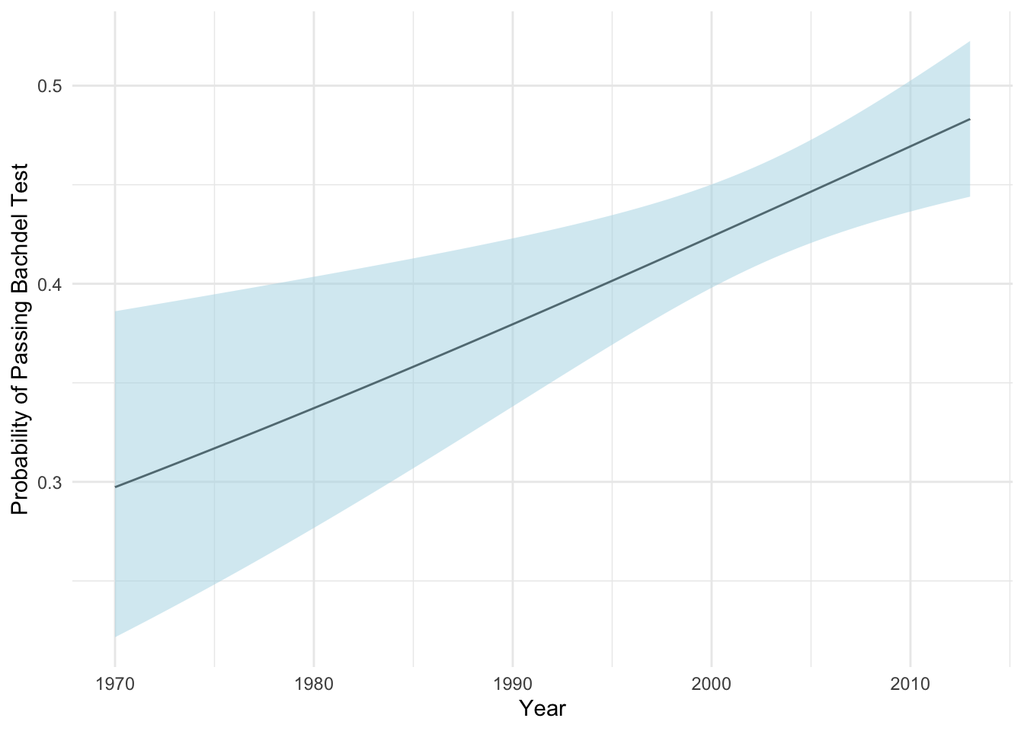

```r
# Your visualization here
plot_data <- movies_clean |>
  summarise(budget_million = mean(budget_million),
    imdb_rating = mean(imdb_rating)) |>
  slice(rep(1, 100)) |>
  mutate(decade = seq(min(movies_clean$decade),
                      max(movies_clean$decade),
                      length.out = 100))

fit_m2 <- predict(m2, plot_data, se.fit = TRUE)
plot_data <- plot_data |>
  mutate(fit_prob = plogis(fit_m2$fit),
  fit_upper = plogis(fit_m2$fit + 1.96*fit_m2$se.fit),
  fit_lower = plogis(fit_m2$fit - 1.96*fit_m2$se.fit))

ggplot(plot_data, aes(x = decade * 10, y = fit_prob)) +
  geom_line(aes(y = fit_prob)) +
  geom_ribbon(aes(ymin = fit_lower, ymax = fit_upper), fill = "lightblue", alpha = 0.5) +
  theme_minimal() +
  labs(x = "Year", y = "Probability of Passing Bachdel Test")
```

**Describe the trend (2-3 sentences):**

The trend of the fitted line is increasing. The width of confidence band is decreasing first from around 1970 - 2000 and then increasing from arond 2000 - 2013.

## Question 3: Comprehensive Analysis (25 points)

**Research Question (descriptive):** Among the movies in this dataset rated G, PG, PG-13 or R, does the relationship between budget and revenue look different across MPAA ratings?

Most movies are PG-13 or R, and there are only 36 G-rated movies, so some patterns will be much less certain than others: say so where it matters. Drop movies with other or missing ratings, and say how many you dropped.

Conduct an appropriate descriptive analysis (your choice of method, for example a regression with an interaction, or one fitted line per rating) and present your findings professionally.

### Your Analysis

```r
# Your code here
movies_clean <- movies |>
  mutate(rated = factor(rated),
  budget_million = budget_2013/1e6,
  revenue_million = (domgross_2013 + intgross_2013)/1e6) |>
  select(title, year, rated, budget_million, revenue_million) |>
  drop_na() |>
  filter(rated %in% c("G", "PG", "PG-13", "R"))

nrow(movies) - nrow(movies_clean)
```

```
[1] 256
```

```r
m3 <- movies_clean |> lm(revenue_million ~ rated + budget_million +
  rated:budget_million, data = _)
summary(m3)
```

```
Call:
lm(formula = revenue_million ~ rated + budget_million + rated:budget_million,
    data = movies_clean)

Residuals:
    Min      1Q  Median      3Q     Max
-914.96 -133.90  -61.65   44.62 2921.58

Coefficients:
                           Estimate Std. Error t value Pr(>|t|)
(Intercept)                185.6312    91.7398   2.023   0.0432 *
ratedPG                      8.2695    97.5200   0.085   0.9324
ratedPG-13                -156.2877    94.0061  -1.663   0.0966 .
ratedR                    -112.7379    93.3060  -1.208   0.2271
budget_million               5.0741     0.9171   5.532 3.71e-08 ***
ratedPG:budget_million      -1.7288     0.9872  -1.751   0.0801 .
ratedPG-13:budget_million   -0.6062     0.9409  -0.644   0.5195
ratedR:budget_million       -2.0271     0.9726  -2.084   0.0373 *
---
Signif. codes:  0 '***' 0.001 '**' 0.01 '*' 0.05 '.' 0.1 ' ' 1

Residual standard error: 318 on 1530 degrees of freedom
Multiple R-squared:  0.3556,    Adjusted R-squared:  0.3527
F-statistic: 120.6 on 7 and 1530 DF,  p-value: < 2.2e-16
```

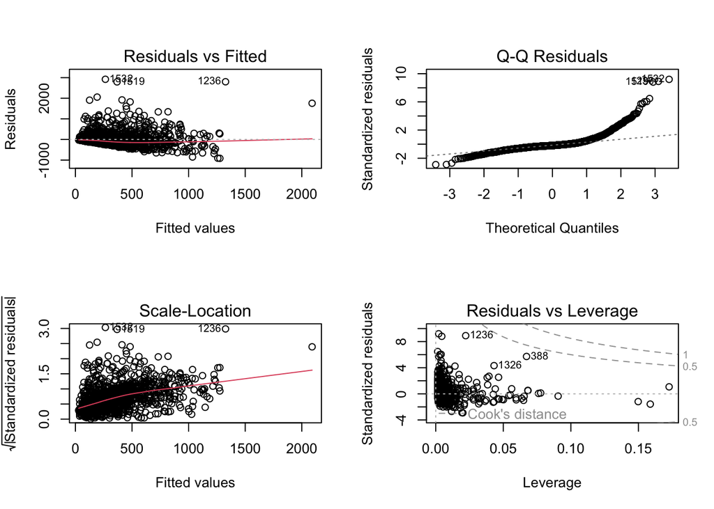

```r
par(mfrow = c(2, 2))
plot(m3)
```

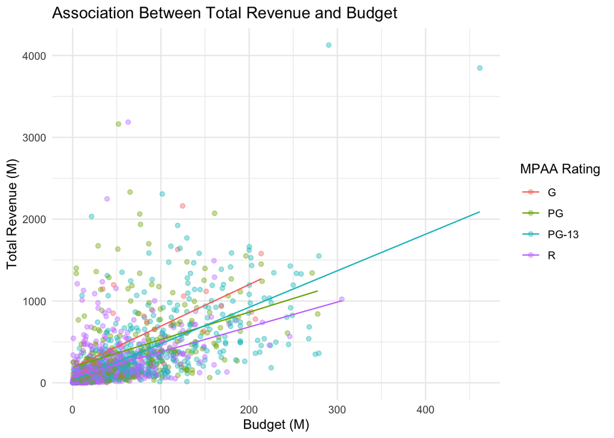

```r
ggplot(movies_clean, aes(x = budget_million, y = revenue_million, colour = rated)) +
  geom_point(alpha = 0.4) +
  geom_line(aes(y = m3$fitted.values)) +
  theme_minimal() +
  labs(title = "Association Between Total Revenue and Budget",
  x = "Budget (M)", y = "Total Revenue (M)",
  colour = "MPAA Rating")
```

```r
g_rows <- which(movies_clean$rated == "G")
length(g_rows)
```

```
[1] 36
```

```r
g_slopes <- numeric(length(g_rows))

for (i in seq_along(g_rows)) {
  movies_temp <- movies_clean[-g_rows[i], ]
  model_temp <- lm(revenue_million ~ rated + budget_million +
      rated:budget_million,data = movies_temp)
  g_slopes[i] <- coef(model_temp)["budget_million"]
}

range(g_slopes)
```

```
[1] 4.571814 5.642775
```

```r
r_slope <- coef(m3)["budget_million"] + coef(m3)["ratedR:budget_million"]

slope_differences <- g_slopes - r_slope

range(slope_differences)
```

```
[1] 1.524839 2.595799
```

```r
all(slope_differences > 0)
```

```
[1] TRUE
```

### Findings

**Write a brief results section (150-200 words) as if for a technical report. Include:**

- Description of your analytical approach
- Key statistical findings
- At least one figure or table
- How stable your main finding is (PCS), for example to the G-rated movies or to the scale you chose
- Interpretation in context of the research question

We analyzed 1,538 movies rated G, PG, PG-13, or R after excluding 256 movies through the rating and missing-data filters. Then we fitted a linear regression model with a budget, rating, and their interactions. The result of the LR shows that budget was positively associated with revenue in every kind of rating. For G-rated movies, every $1 million higher budget corresponded to an predicted $5.07 million higher revenue , compared with $3.35 million for PG, $4.47 million for PG-13, and $3.05 million for R. However, from the t-tests for the interaction terms, the difference between the slope of G and the slope of R is statistically significant, while the PG and PG-13 slope differences from G were not. And the R^2 shows that the model explained 35.6% of revenue variation. To evaluate the stability of our finding, we used leave-one-out method by removing each G-rated movie in one turn and refitting 36 new models. The slope difference between G and R ranged from 1.52 to 2.60 and remained positive, compared with 2.03 in the full sample. Thus, the direction of this comparison was stable, although its magnitude varied.

## Question 4: Same Data, Different Goals (15 points)

Choose **one** of Questions 1-3. Suppose the goal were not description:

1. **Inference.** You want to make claims about a larger population of movies. What population could that be, and is this dataset a good sample of it? What would you change about how you choose the model, which assumptions you check, and what you report?
2. **Prediction.** You want to predict the outcome for a *new* movie. When would the prediction be made (for example, before release)? Which variables would actually be available at that time? How would you choose the model, measure how well it predicts, and what would you report?

**Your answer (200-300 words, covering both a and b):**

## Submission Checklist

- All code runs without errors
- Code is hidden in the HTML (`code-fold: true`)
- All interpretations are in your own words and contextual
- Figures have proper labels and captions
- Tables are well-formatted
- Statistical results include relevant values (effect sizes, and p-values or confidence intervals where requested)
- Conclusions describe these movies, with no causal claims or claims about all movies
- Each model reports how many movies it uses
- No AI tools were used (per the syllabus AI Policy)

## References

TidyTuesday: Bechdel Test (2021-03-09). Data from FiveThirtyEight and The Bechdel Test website.  
https://github.com/rfordatascience/tidytuesday/blob/master/data/2021/2021-03-09/readme.md